# Red Wine Quality Analysis

## Bivariate Analysis:

### Fixed.acidity seems to have little to no effect on quality

### Quality seems to go up when volatile.acidity goes down. The higher ranges seem to produce more average and poor wines.Better wines tend to have higher concentration of citric acid.

### Contrary to what I initially expected residual.sugar apparently seems to have little to no effect on perceived quality.Altough weakly correlated, a lower concentration of chlorides seem to produce better wines.Better wines tend to have lower densities.

### In terms of pH it seems better wines are more acid but there were many outliers. Better wines also seem to have a higher concentration of sulphates.

### Alcohol graduation has a strong correlation with quality, but like the linear model showed us it cannot explain all the variance alone. We’re going to need to look at the other variables to generate a better model.

### Other than the main feature of interest i observe interesting relationships between the other below features:

### I verified the strong relation between free and total sulfur.dioxide.

### Strong relation between fixed acidity and citric acid.

### Strong relation between fixed acidity and volatile acidity.

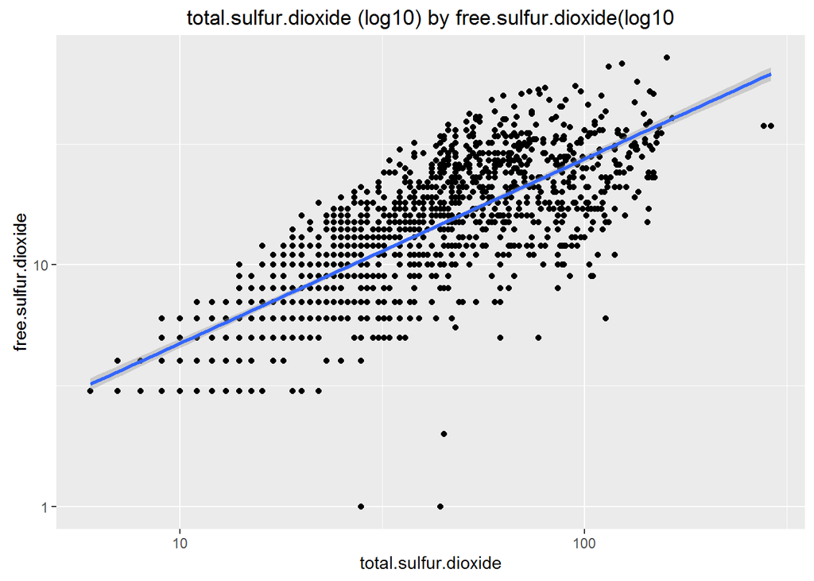

```
##
##  Pearson's product-moment correlation
##
## data:  wine$free.sulfur.dioxide and wine$total.sulfur.dioxide
## t = 35.8402, df = 1597, p-value < 2.2e-16
## alternative hypothesis: true correlation is not equal to 0
## 95 percent confidence interval:
##  0.6395786 0.6939740
## sample estimates:
##       cor
## 0.6676665
```

### The strongest relationship I found was between the variables total.sulfur.dioxide and free.sulfur.dioxide.

## Multivariate Plots:

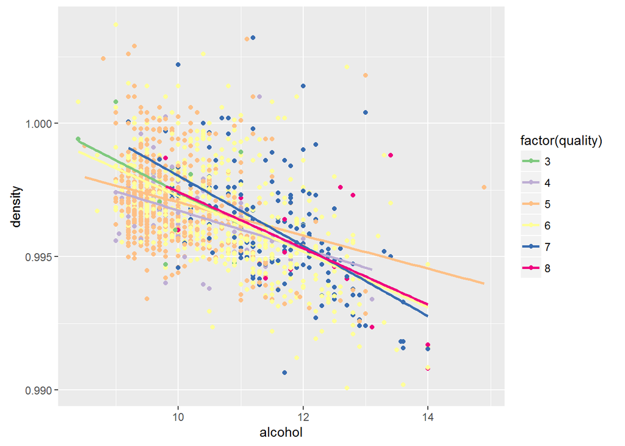

### When we hold alcohol constant, there is no evidence that density affects quality whereas previous bivariate plot showed that density had an impact on the quality of wine.

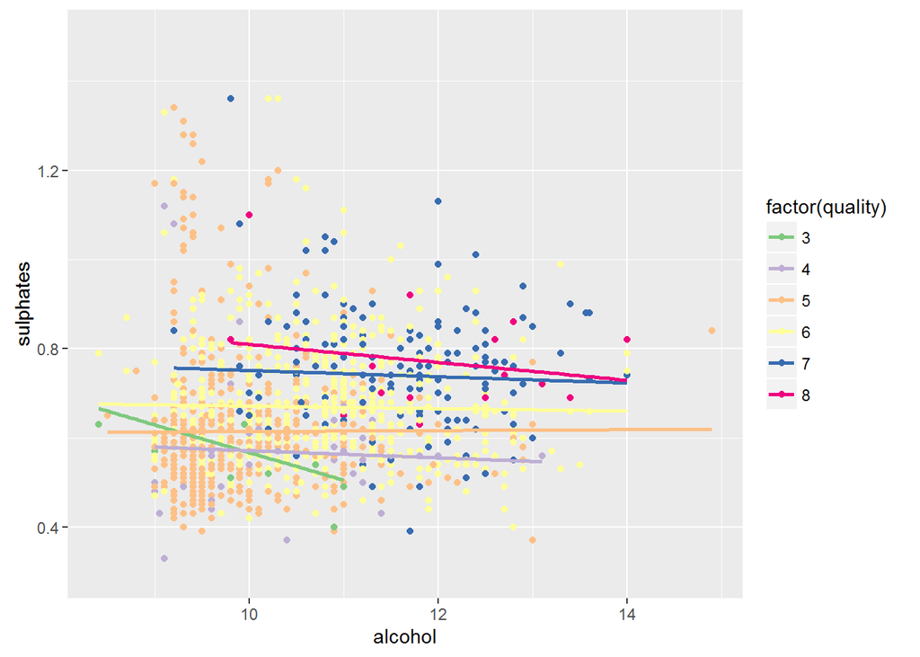

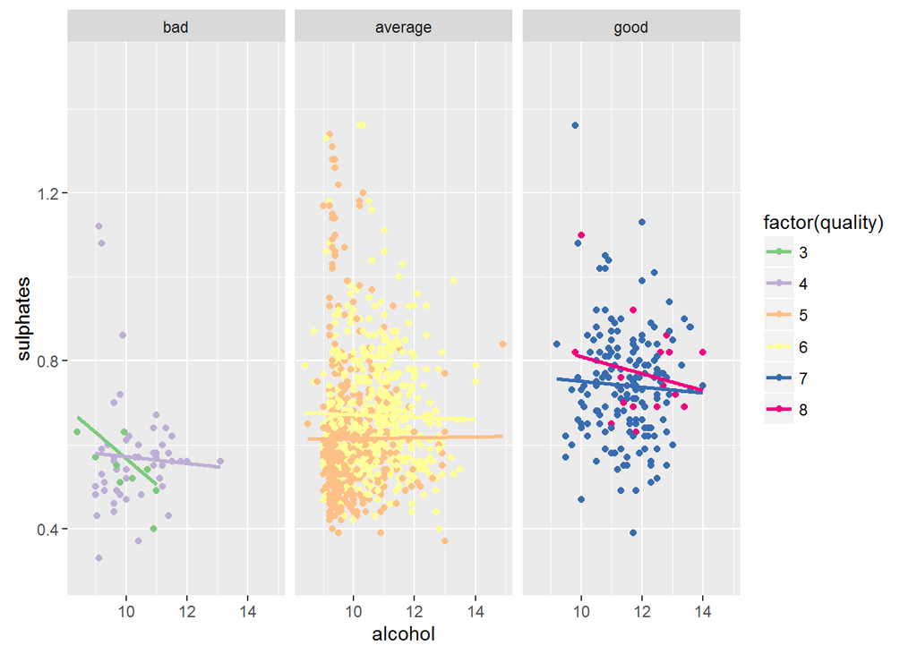

### It seems that for wines with high alcohol content, having a higher concentration of sulphates produces better wines.

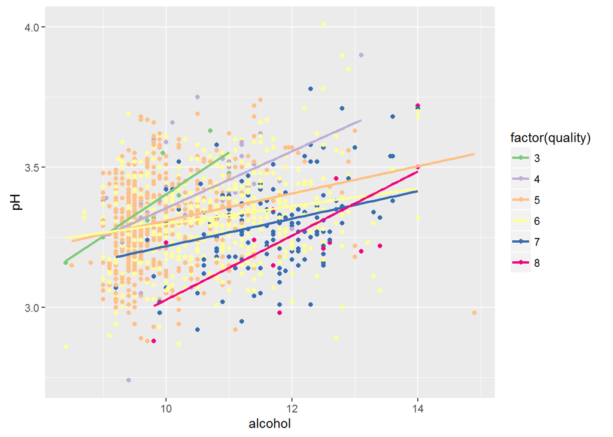

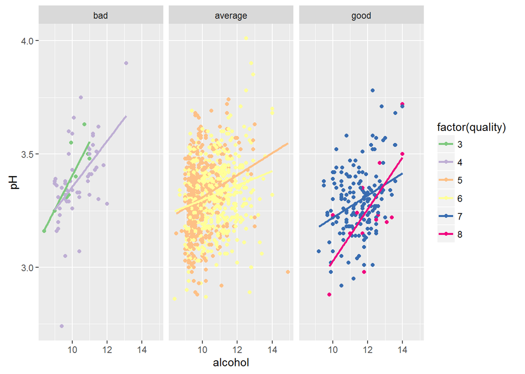

###Low pH and high alcohol concentration seem to be a good match.

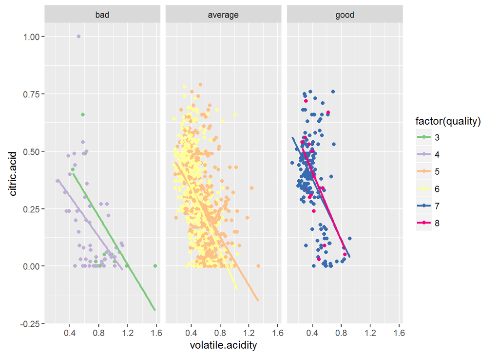

###High citric acid and low acetic acid seems like a good combination.

## Linear model

```
##
## Calls:
## m1: lm(formula = quality ~ alcohol, data = wine)
## m2: lm(formula = quality ~ alcohol + sulphates, data = wine)
## m3: lm(formula = quality ~ alcohol + sulphates + volatile.acidity,
##     data = wine)
## m4: lm(formula = quality ~ alcohol + sulphates + volatile.acidity +
##     citric.acid, data = wine)
## m5: lm(formula = quality ~ alcohol + sulphates + volatile.acidity +
##     citric.acid + fixed.acidity, data = wine)
##
## ===========================================================================
##                        m1         m2         m3         m4         m5
## ---------------------------------------------------------------------------
##   (Intercept)        1.875***   1.375***   2.611***   2.646***   2.202***
##                     (0.175)    (0.177)    (0.196)    (0.201)    (0.224)
##   alcohol            0.361***   0.346***   0.309***   0.309***   0.320***
##                     (0.017)    (0.016)    (0.016)    (0.016)    (0.016)
##   sulphates                     0.994***   0.679***   0.696***   0.701***
##                                (0.102)    (0.101)    (0.103)    (0.103)
##   volatile.acidity                        -1.221***  -1.265***  -1.343***
##                                           (0.097)    (0.113)    (0.113)
##   citric.acid                                        -0.079     -0.469***
##                                                      (0.104)    (0.137)
##   fixed.acidity                                                  0.057***
##                                                                 (0.013)
## ---------------------------------------------------------------------------
##   R-squared              0.2        0.3        0.3        0.3        0.3
##   adj. R-squared         0.2        0.3        0.3        0.3        0.3
##   sigma                  0.7        0.7        0.7        0.7        0.7
##   F                    468.3      295.0      268.9      201.8      167.0
##   p                      0.0        0.0        0.0        0.0        0.0
##   Log-likelihood     -1721.1    -1675.1    -1599.4    -1599.1    -1589.6
##   Deviance             805.9      760.9      692.1      691.9      683.7
##   AIC                 3448.1     3358.3     3208.8     3210.2     3193.3
##   BIC                 3464.2     3379.8     3235.7     3242.4     3230.9
##   N                   1599       1599       1599       1599       1599
## ===========================================================================
```

## Final Plots and Summary

### Plot 1: Effect of acid on wine quality

[figure not shown]

### Plot 2: Effect of alcohol on wine quality

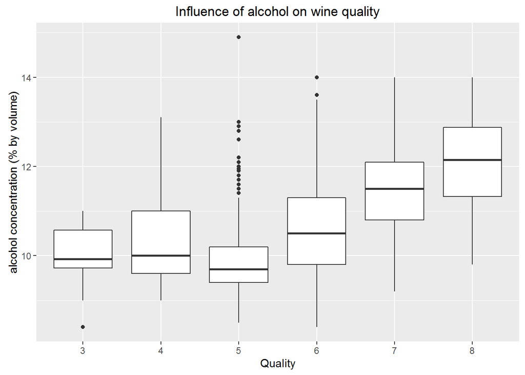

### These boxplots demonstrate the effect of alcohol content on wine quality. Generally, higher alcohol content correlated with higher wine quality. However, as the outliers and intervals show, alchol content alone did not produce a higher quality.

### Plot 3: What makes good wines, good, and bad wines, bad?

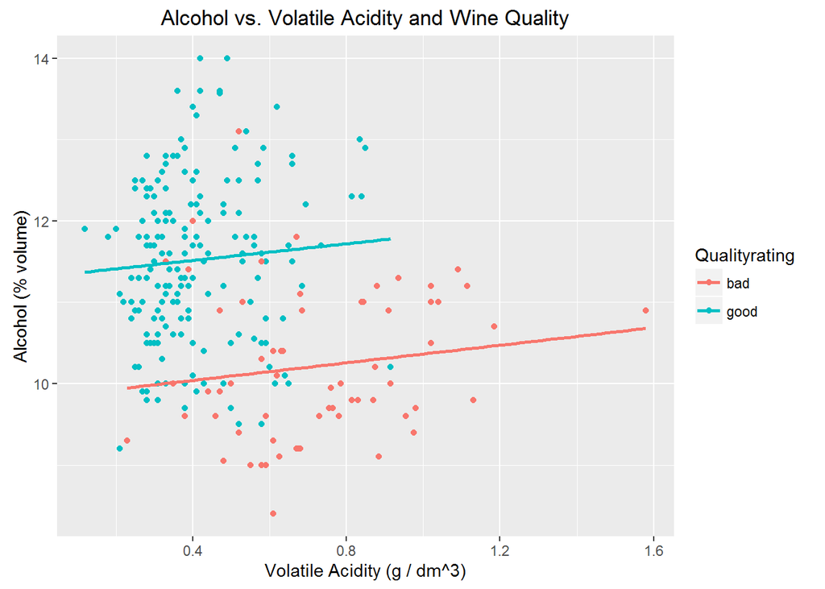

# Reflection

### The wine data set contains information on the chemical properties of a selection of wines collected in 2009. It also includes sensorial data (wine ranking).I started by looking at the individual distributions of the variables, trying to get a feel for each one.

### The first thing I noticed was the high concentration of wines in the middle ranges of the ranking, that is, average tasting wines. This proved to be very problematic during the analysis as I kept questioning myself wether there was a true correlation between two variables or it was just a coincidence given the lack of “outlier” (poor and excellent) wines.

### After exploring the individual variables, I proceded to investigate the relationships between each input variable and the outcome variable quality.The most promissing varibles were alcohol concentration, sulphates and the individual acid concentrations.

### On the final part of the analysis I tried using multivariate plots to investigate if there were interesting combinations of variables that might affect quality. I also used a multivariate plot to confirm that density did not have an effect on quality when holding alcohol concentration constant.In the end, the produced model could not explain much of the variance in quality. This is further corroborated acidity analysis.

### For future studies, it would be interesting to mesure more acid types in the analysis. Wikipedia for example, suggests that malic and lactic acid are important in wine taste and these were not included in this sample.